# LAB8

Jonathan Ifegunni

October 11, 2018

# TASK 1

```r
getwd()
```

```
## [1] "C:/Users/obi4m/OneDrive/Desktop/maths/LAB8"
```

# TASK 2

## a)

```r
unif = runif(10,0,5)
unif
```

```
##  [1] 4.329415 3.124374 3.789132 3.663778 0.123578 4.229072 1.796110
##  [8] 1.426490 2.435648 2.343031
```

## b)

```r
# mean and variance
mean = (0+5)/2
mean
```

```
## [1] 2.5
```

```r
# Variance
var = (5-0)^2/12
var
```

```
## [1] 2.083333
```

## c)

```r
# mean/ variance of sample
mus = mean(unif)
mus
```

```
## [1] 2.726063
```

```r
vars = (sd(unif))^2 #variance
vars
```

```
## [1] 1.839504
```

## d)

### i)

$$E(T) = nE(Y_i)$$

```r
# For the sum T
sT_mean = 10*mean
sT_mean
```

```
## [1] 25
```

$$V(T) = nV(Y_i)$$

```r
sT_var = 10*var
sT_var
```

```
## [1] 20.83333
```

### ii)

$$E(\bar Y) = E(Y_i)$$

```r
# for the mean Y
muY_mean = mean
muY_mean
```

```
## [1] 2.5
```

$$V(\bar Y) = \frac{V(Y_i)}{n}$$

```r
# for the variance Y
varY_mean = var/10
varY_mean
```

```
## [1] 0.2083333
```

## e)

### i)

This line creates n*iter uniformly distributed random variables from a = 0 to b = 5

### ii)

First, creates a matrix data specified by nr rows and nc columns and then fills the matrix by row with the values of the vector y.

### iii)

Sums up the matrix created in B across each column. Returns the result of the sums into the variable sm.

### iv)

This line is a call to the myclt function specifying values for n = 10 and iter (number of iterations) = 10000. This will run the whole function for this values.

## f)

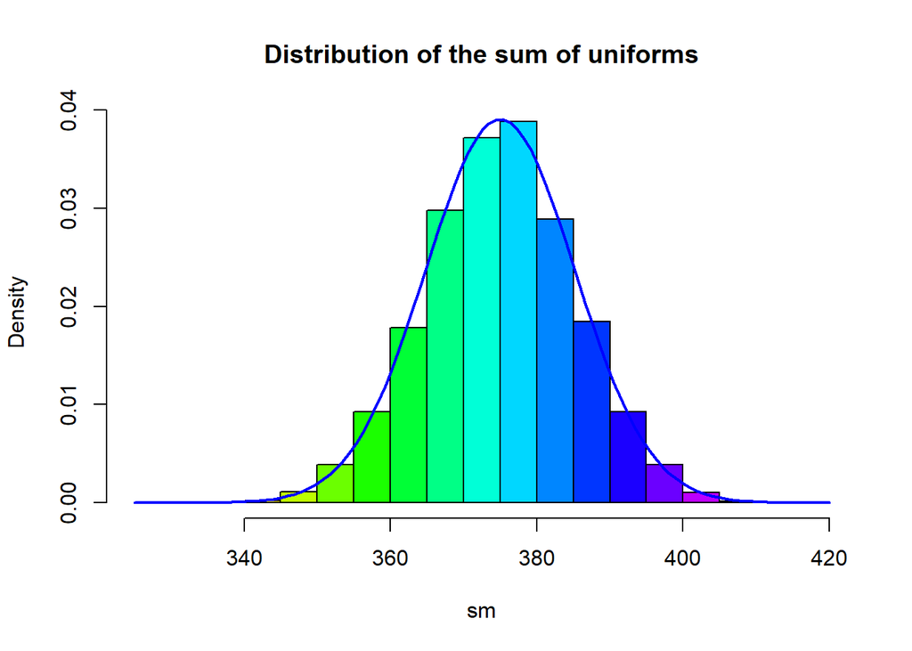

```r
myclt=function(n,iter,a=0,b=5){
y=runif(n*iter,a,b)
data=matrix(y,nr=n,nc=iter,byrow=TRUE)
sm=apply(data,2,sum)
h=hist(sm,plot=FALSE)
hist(sm,col=rainbow(length(h$mids)),freq=FALSE,main="Distribution of the sum of uniforms")
curve(dnorm(x,mean=n*(a+b)/2,sd=sqrt(n*(b-a)^2/12)),add=TRUE,lwd=2,col="Blue")
sm
}
w=myclt(n=50,iter=10000,a=5,b=10)
```

## g)

```r
w=myclt(n=10,iter=10000)
```

[figure not shown]

```r
# sample estimates mean
mu_w = mean(w)
mu_w
```

```
## [1] 24.95989
```

```r
#variance
var_w = var(w)
var_w
```

```
## [1] 20.57694
```

## i)

```r
# sample estimates
mu_w = mean(w)
mu_w
```

```
## [1] 24.95989
```

```r
var_w = var(w)
var_w
```

```
## [1] 20.57694
```

# TASK 3

## a)

```r
### CLT uniform
## my Central Limit Function
## Notice that I have assigned default values which can be changed when the function is called
mycltu=function(n,iter,a=0,b=10){
  ## r-random sample from the uniform
  y=runif(n*iter,a,b)
  ## Place these numbers into a matrix
  ## The columns will correspond to the iteration and the rows will equal the sample size n
  data=matrix(y,nr=n,nc=iter,byrow=TRUE)
  ## apply the function mean to the columns (2) of the matrix
  ## these are placed in a vector w
  w=apply(data,2,mean)
  ## We will make a histogram of the values in w
  ## How high should we make y axis?
  ## All the values used to make a histogram are placed in param (nothing is plotted yet)
  param=hist(w,plot=FALSE)
  ## Since the histogram will be a density plot we will find the max density

  ymax=max(param$density)
  ## To be on the safe side we will add 10% more to this
  ymax=1.1*ymax
  ## Now we can make the histogram
  hist(w,freq=FALSE,  ylim=c(0,ymax), main=paste("Histogram of sample mean",
                                                 "\n", "sample size= ",n,sep=""),xlab="Sample mean")
  ## add a density curve made from the sample distribution
  lines(density(w),col="Blue",lwd=3) # add a density plot
  ## Add a theoretical normal curve
  curve(dnorm(x,mean=(a+b)/2,sd=(b-a)/(sqrt(12*n))),add=TRUE,col="Red",lty=2,lwd=3) # add a theoretical curve
  ## Add the density from which the samples were taken
  curve(dunif(x,a,b),add=TRUE,lwd=4)
}
```

## b)

### i)

$$Orginal\ distribution\ \sigma^2 = \frac{(b-a)^2}{12}\\
sample\ mean\ variances\ \sigma^2_m = \frac{(b-a)^2}{12n}\\
sample\ mean\ sd\ \sigma=\frac{b-a}{\sqrt{12n}}$$

## c)

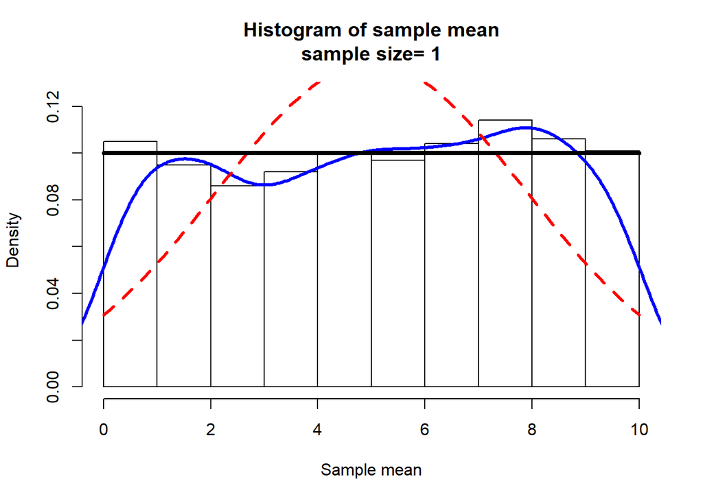

```r
# n=1, iter=10000, a=0,b=10
mycltu(n = 1, iter =1000, a = 0, b = 10)
```

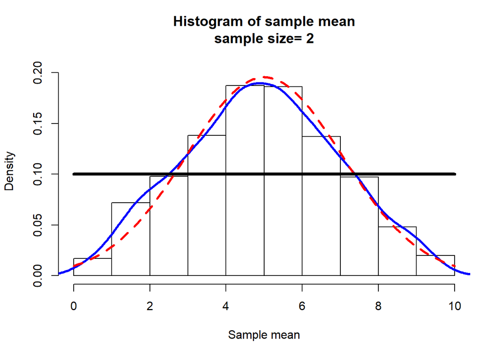

```r
# n=2, iter=10000, a=0,b=10
mycltu(n =2, iter =1000, a = 0, b = 10)
```

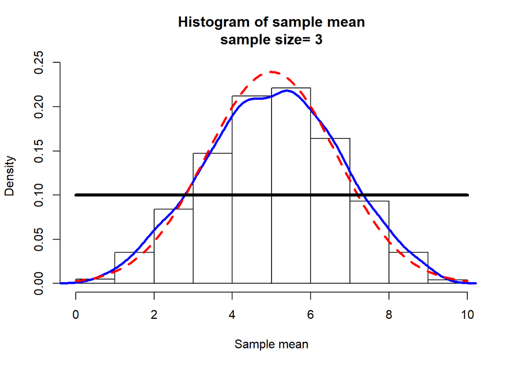

```r
#   n=3,iter=10000,a=0,b=10
mycltu(n = 3, iter =1000, a = 0, b = 10)
```

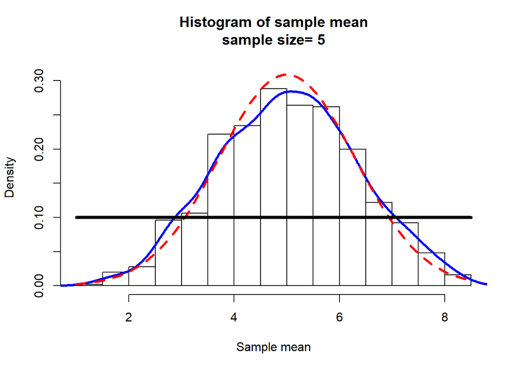

```r
#   n=5,iter=10000,a=0,b=10
mycltu(n = 5, iter =1000, a = 0, b = 10)
```

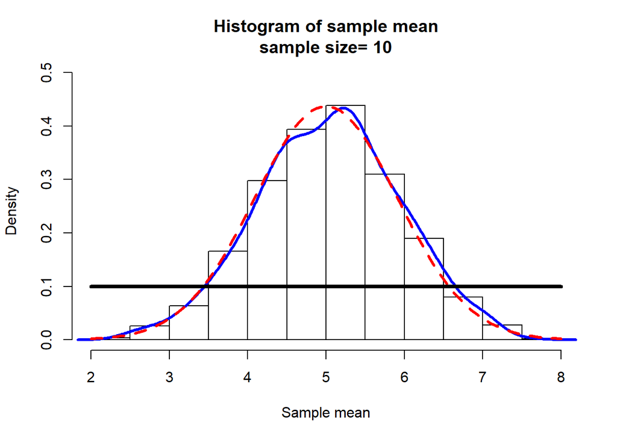

```r
#   n=10, iter=10000,a=0,b=10
mycltu(n =10, iter =1000, a = 0, b = 10)
```

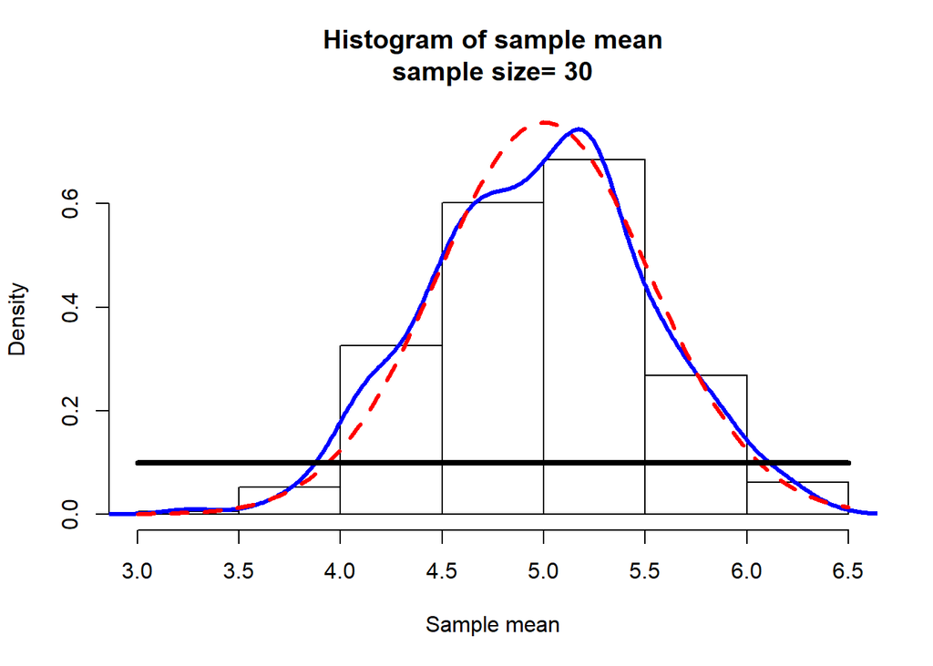

```r
#n=30,iter=10000,a=0,b=10
mycltu(n =30, iter =1000, a = 0, b = 10)
```

## d)

I can see from the plots that the sample mean distribution obeys the central limit theorem. For a sample size of 1, the sample mean has a uniform distribution which is to be expected, since the population being sampled also has a uniform distribution. However as the sample size increases, the sample mean distribution starts to approach the normal distribution. This is clear for n =10 where the theoretical line for the normal distribution (in red) matches very closely with the density curve (blue) of the sampled distribution. Thus, the sampling distribution approaches the Normal, as n approaches infinity.

# TASK 4

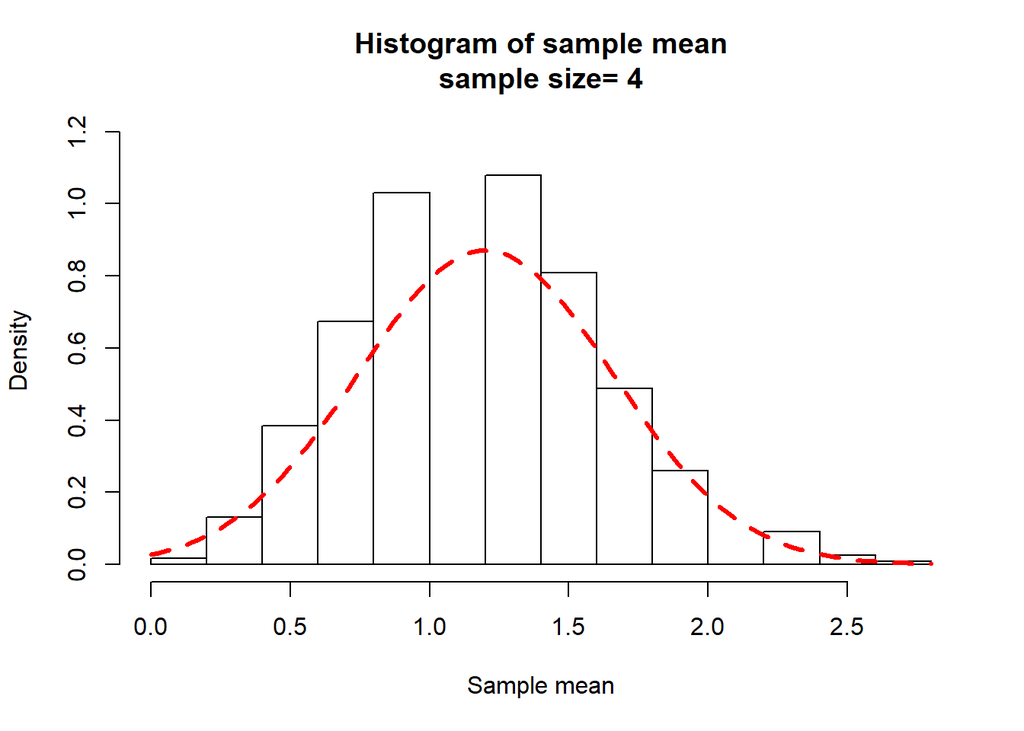

```r
mycltb=function(n,iter,p=0.5,...){

  ## r-random sample from the Binomial
  y=rbinom(n*iter,size=n,prob=p)
  ## Place these numbers into a matrix
  ## The columns will correspond to the iteration and the rows will equal the sample size n
  data=matrix(y,nr=n,nc=iter,byrow=TRUE)
  ## apply the function mean to the columns (2) of the matrix
  ## these are placed in a vector w
  w=apply(data,2,mean)
  ## We will make a histogram of the values in w
  ## How high should we make y axis?
  ## All the values used to make a histogram are placed in param (nothing is plotted yet)
  param=hist(w,plot=FALSE)
  ## Since the histogram will be a density plot we will find the max density

  ymax=max(param$density)
  ## To be on the safe side we will add 10% more to this
  ymax=1.1*ymax

  ## Now we can make the histogram
  ## freq=FALSE means take a density
  hist(w,freq=FALSE,  ylim=c(0,ymax),
       main=paste("Histogram of sample mean","\n", "sample size= ",n,sep=""),
       xlab="Sample mean",...)
  ## add a density curve made from the sample distribution
  #lines(density(w),col="Blue",lwd=3) # add a density plot
  ## Add a theoretical normal curve
  curve(dnorm(x,mean=n*p,sd=sqrt(p*(1-p))),add=TRUE,col="Red",lty=2,lwd=3)

}

#   n=4,iter=10000,p=0.3
mycltb(n=4,iter=10000,p=0.3)
```

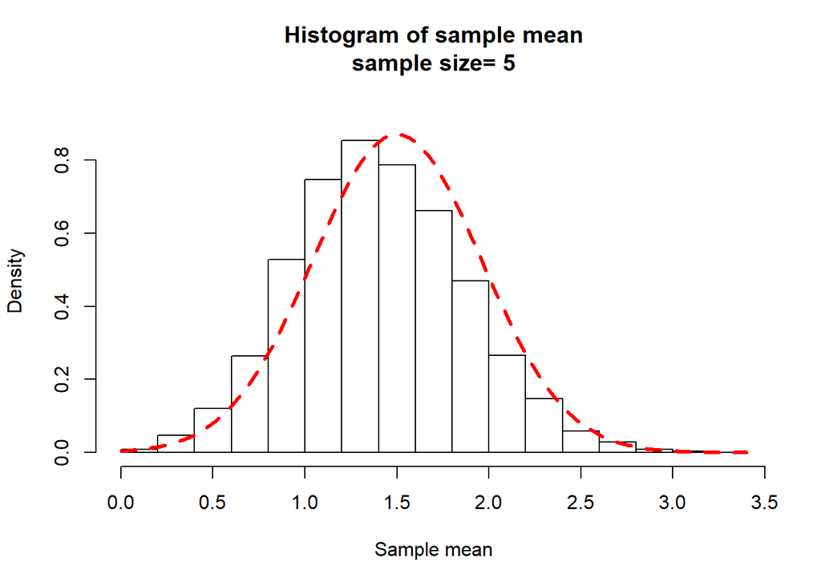

```r
#   n=5,iter=10000,p=0.3
mycltb(n=5,iter=10000,p=0.3)
```

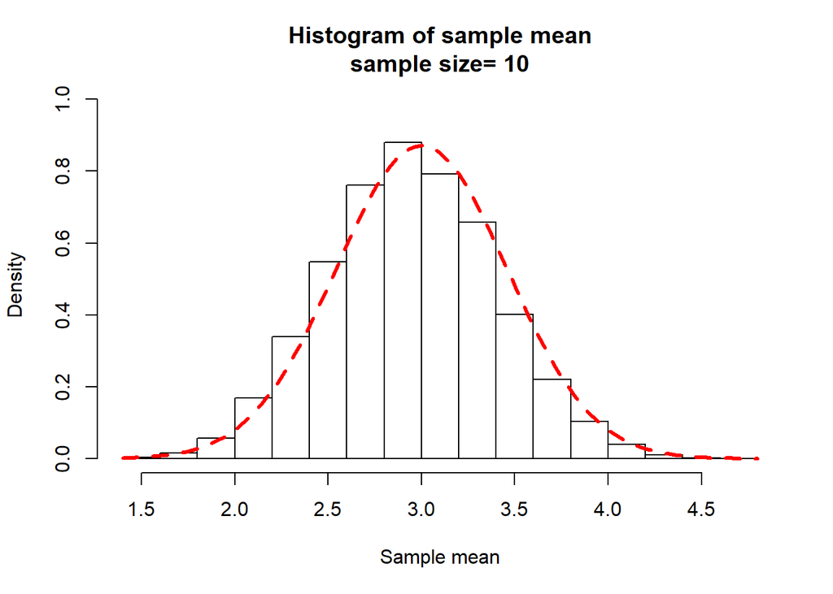

```r
#   n=10,iter=10000,p=0.3
mycltb(n=10,iter=10000,p=0.3)
```

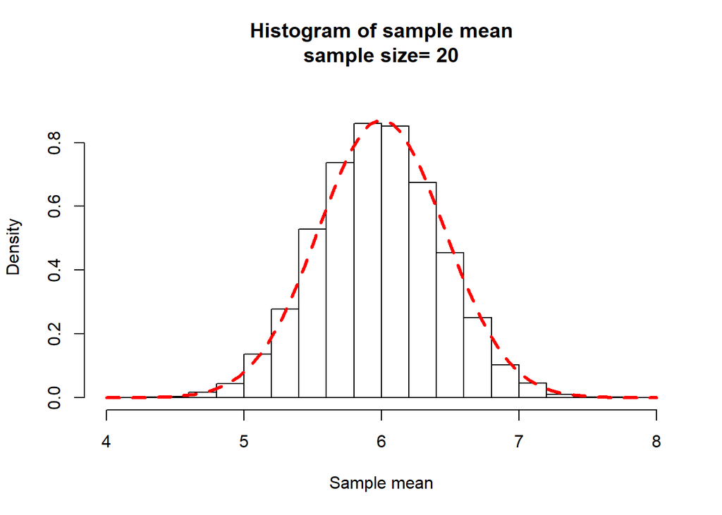

```r
#   n=20,iter=10000,p=0.3
mycltb(n=20,iter=10000,p=0.3)
```

## b)

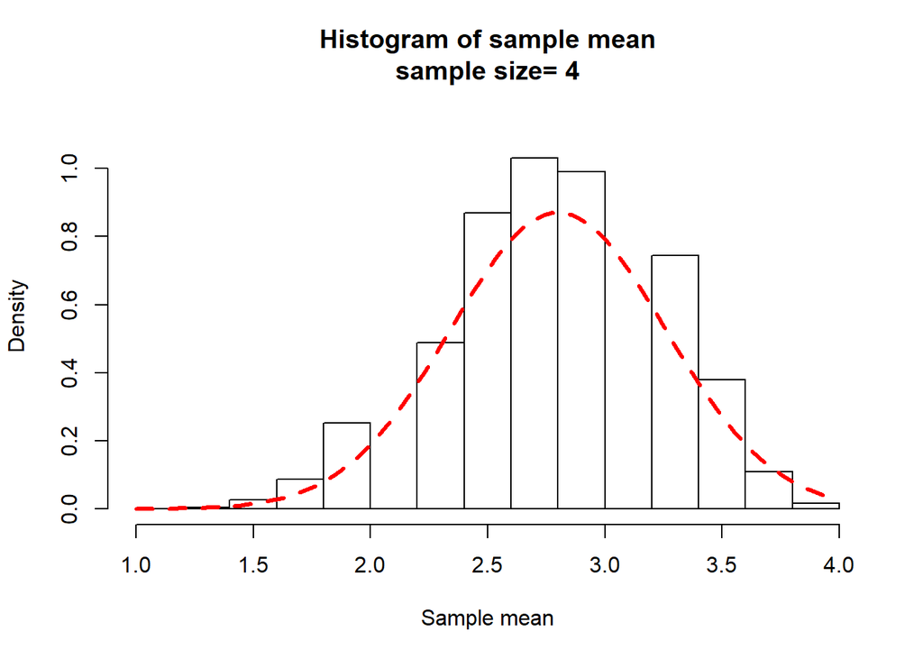

```r
## using p=0.7
#   n=4,iter=10000,p=0.7
mycltb(n=4,iter=10000,p=0.7)
```

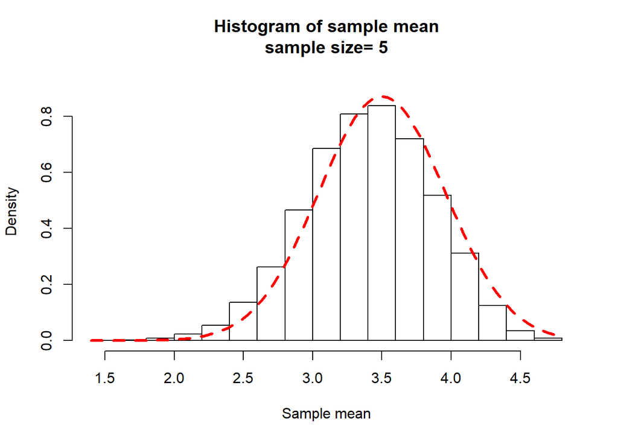

```r
#   n=5,iter=10000,p=0.7
mycltb(n=5,iter=10000,p=0.7)
```

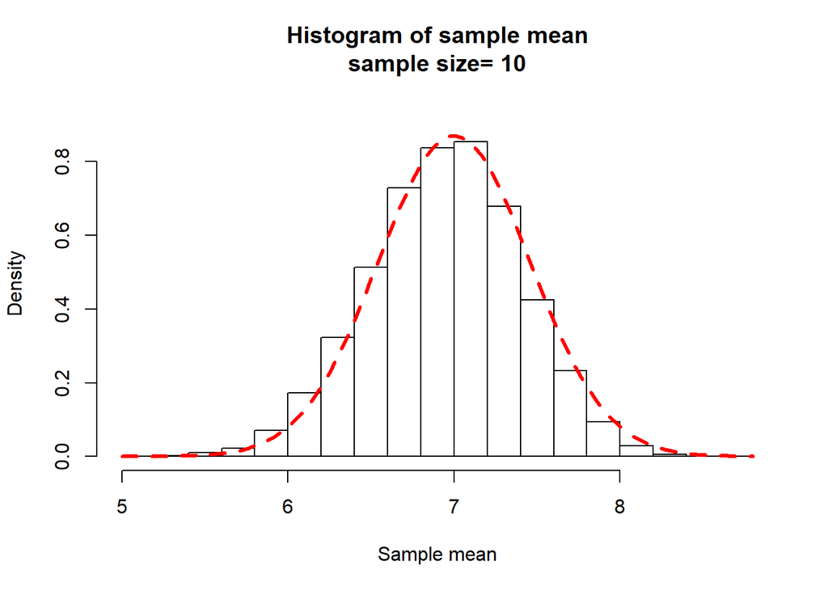

```r
#   n=10,iter=10000,p=0.7
mycltb(n=10,iter=10000,p=0.7)
```

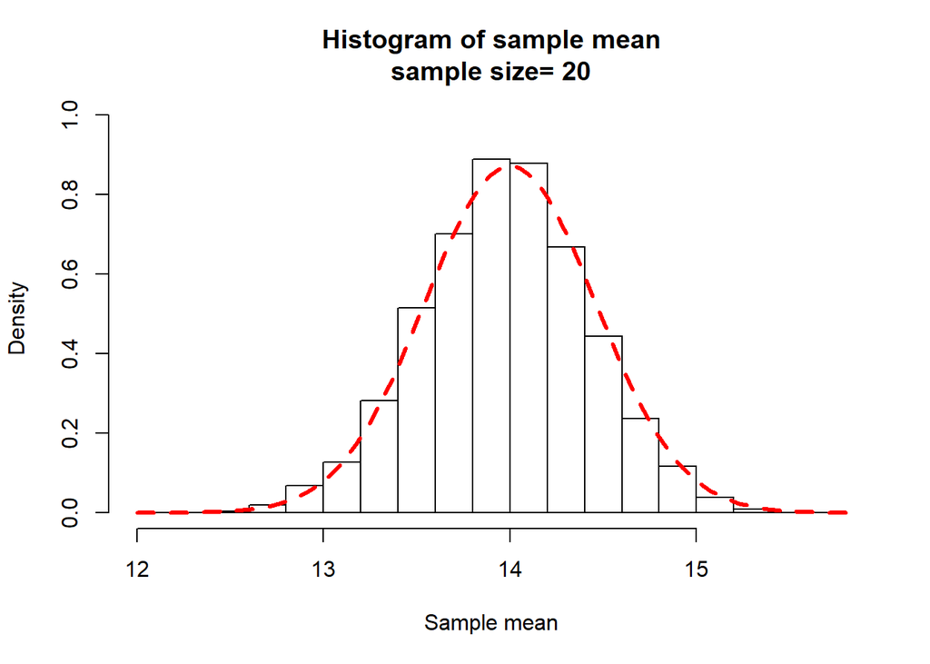

```r
#   n=20,iter=10000,p=0.7
mycltb(n=20,iter=10000,p=0.7)
```

## c)

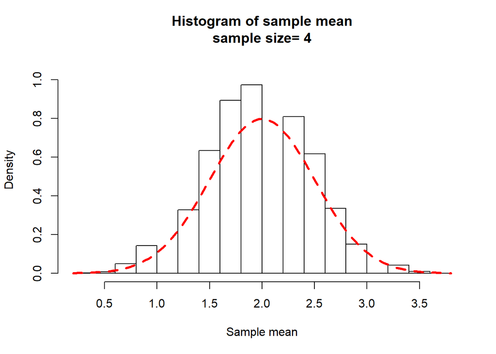

```r
## using p=0.5
#   n=4,iter=10000,p=0.5
mycltb(n=4,iter=10000,p=0.5)
```

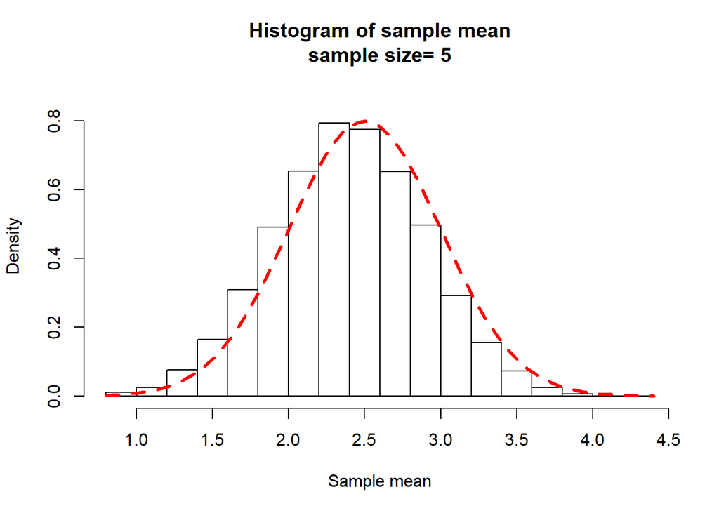

```r
#   n=5,iter=10000,p=0.7
mycltb(n=5,iter=10000,p=0.5)
```

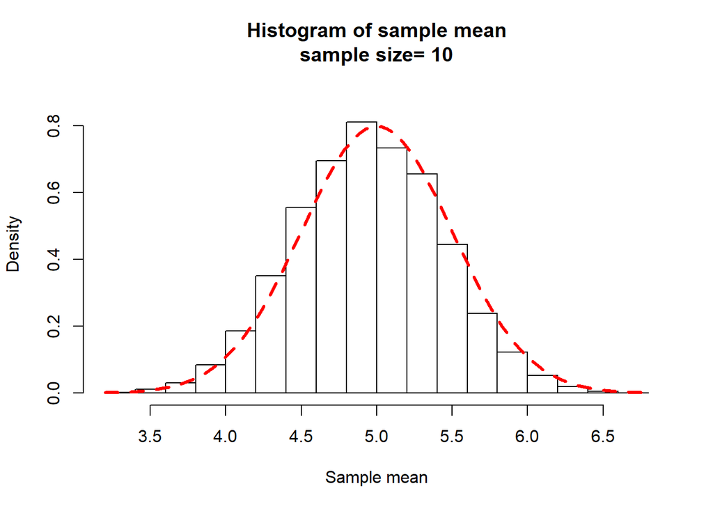

```r
#   n=10,iter=10000,p=0.7
mycltb(n=10,iter=10000,p=0.5)
```

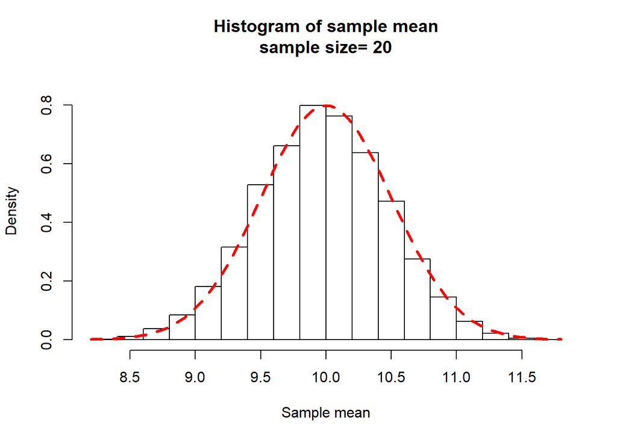

```r
#   n=20,iter=10000,p=0.7
mycltb(n=20,iter=10000,p=0.5)
```